# Analyzing Hotel Booking Data to Predict Cancelltions

# Spring 2024 Data Science Project

Contributors: Tarun Thatavarthi - Solo Project

When I went to India this summer, I got to visit my uncle: who runs a chain of hotels in Chennai. Specificallly, I wanted to stay at his resort in Goa- but due to cancellations, in the 4 years since I had last visited him, he decided to close the Goa chain down: it was too much work having staff hustle around when the reservation was probably getting cancelled anyways, and he cared alot about the ease-of-life for his employees.

In the hotel business, cancellations are by far the loss-leader when it comes to the bottom line: it's a necessary evil that all owners must learn to navigate around if they want to last in the industry. For this project, our goal is to analzye hotel booking data to see if we can predict a cancellation before it happens: and save my Uncle some cash 😵.

These are some tabs to each step of our data analysis process.

Data Collection Data Processing Exploratory Analysis & Data Visualization Model: Analysis, Hypothesis Testing, & ML Interpretation: Insight & Policy Decision

# Data Collection

These are the imports we are going to need for this project: there are alot of specific things here that you might not be aware of, but we will learn about them as we go. I will provide links and necessary info at each step, but for now the only thing you need to know is how to use pandas and numpy at a basic level. Here is some documentation that might be useful:

https://numpy.org/doc/stable/user/absolute_beginners.html

https://pandas.pydata.org/docs/user_guide/10min.html

https://scikit-learn.org/stable/

```python
import requests
from bs4 import BeautifulSoup as bs
import pandas as pd
import datetime as dt
from datetime import datetime
import numpy as np
import matplotlib.pyplot as plt
import seaborn as sns
import tensorflow as tf
from tensorflow import keras
import math
from sklearn.model_selection import cross_validate, train_test_split, GridSearchCV
from sklearn.preprocessing import MinMaxScaler, StandardScaler, LabelEncoder
from sklearn.linear_model import LogisticRegression
from sklearn.neighbors import KNeighborsClassifier
from sklearn.ensemble import RandomForestRegressor, RandomForestClassifier
from scipy.stats import ttest_ind, chi2_contingency, shapiro, levene, pointbiserialr, f_oneway
import statsmodels.api as sm
import geopandas as gpd
import folium
from sklearn.metrics import accuracy_score, confusion_matrix, classification_report, roc_curve, roc_auc_score
from sklearn.inspection import permutation_importance
from sklearn.tree import DecisionTreeRegressor, DecisionTreeClassifier
from sklearn.model_selection import cross_val_score
import statsmodels.api as sm
from statsmodels.formula.api import ols
from scipy.stats import levene
from statsmodels.stats.proportion import proportions_ztest
from sklearn import tree
```

# Data Processing

Lets start by importing our data.

We are reading this CSV, Hotel_Bookings.csv, into a dataframe that hold all necesarry information for the rest of this tutorial.

```python
df = pd.read_csv("hotel_bookings.csv")
```

Let's think about how a computer might see data. For example, is there any actual difference between June and July, or May and August? Computers dont necessarily understand the seasons just for their names. However, its probably easier for them to see at what interval in the year it was at. Let's convert the months into numbers.

```python
month_mapping = {
    'January': 1, 'February': 2, 'March': 3, 'April': 4,
    'May': 5, 'June': 6, 'July': 7, 'August': 8,
    'September': 9, 'October': 10, 'November': 11, 'December': 12
}

df['arrival_date_month'] = df['arrival_date_month'].map(month_mapping)
df['reservation_status_date']= pd.to_datetime(df['reservation_status_date'])
```

```python
print(df.isnull().sum())
```

```
hotel                                  0
is_canceled                            0
lead_time                              0
arrival_date_year                      0
arrival_date_month                     0
arrival_date_week_number               0
arrival_date_day_of_month              0
stays_in_weekend_nights                0
stays_in_week_nights                   0
adults                                 0
children                               4
babies                                 0
meal                                   0
country                              488
market_segment                         0
distribution_channel                   0
is_repeated_guest                      0
previous_cancellations                 0
previous_bookings_not_canceled         0
reserved_room_type                     0
assigned_room_type                     0
booking_changes                        0
deposit_type                           0
agent                              16340
company                           112593
days_in_waiting_list                   0
customer_type                          0
adr                                    0
required_car_parking_spaces            0
total_of_special_requests              0
reservation_status                     0
reservation_status_date                0
dtype: int64
```

Most of these are pretty Negligible except for the company, of which almost our entire dataset has a NULL value for. We have enoiugh information besides the company to be able to draw conclusions, so lets remove this for now.

```python
df.drop(['company'], axis =1, inplace = True)
```

agent NULL NULL NULL 304 240 240 NULL 303 240

After looking into the dataset, these numbers are ananoymzied datapoints that represent the ID: not something we can really pull insights out of. Let's drop this as well.

```python
df.drop(['agent'], axis =1, inplace = True)
```

```python
filter = (df.children == 0) & (df.adults == 0) & (df.babies == 0)
df[filter]
```

|  | hotel | is_canceled | lead_time | arrival_date_year | arrival_date_month | arrival_date_week_number | arrival_date_day_of_month | stays_in_weekend_nights | stays_in_week_nights | adults | ... | assigned_room_type | booking_changes | deposit_type | days_in_waiting_list | customer_type | adr | required_car_parking_spaces | total_of_special_requests | reservation_status | reservation_status_date |
| --- | --- | --- | --- | --- | --- | --- | --- | --- | --- | --- | --- | --- | --- | --- | --- | --- | --- | --- | --- | --- | --- |
| 2224 | Resort Hotel | 0 | 1 | 2015 | 10 | 41 | 6 | 0 | 3 | 0 | ... | I | 1 | No Deposit | 0 | Transient-Party | 0.00 | 0 | 0 | Check-Out | 2015-10-06 |
| 2409 | Resort Hotel | 0 | 0 | 2015 | 10 | 42 | 12 | 0 | 0 | 0 | ... | I | 0 | No Deposit | 0 | Transient | 0.00 | 0 | 0 | Check-Out | 2015-10-12 |
| 3181 | Resort Hotel | 0 | 36 | 2015 | 11 | 47 | 20 | 1 | 2 | 0 | ... | C | 0 | No Deposit | 0 | Transient-Party | 0.00 | 0 | 0 | Check-Out | 2015-11-23 |
| 3684 | Resort Hotel | 0 | 165 | 2015 | 12 | 53 | 30 | 1 | 4 | 0 | ... | A | 1 | No Deposit | 122 | Transient-Party | 0.00 | 0 | 0 | Check-Out | 2016-01-04 |
| 3708 | Resort Hotel | 0 | 165 | 2015 | 12 | 53 | 30 | 2 | 4 | 0 | ... | C | 1 | No Deposit | 122 | Transient-Party | 0.00 | 0 | 0 | Check-Out | 2016-01-05 |
| 4127 | Resort Hotel | 1 | 0 | 2016 | 2 | 8 | 15 | 0 | 0 | 0 | ... | P | 0 | No Deposit | 0 | Transient | 0.00 | 0 | 0 | Canceled | 2016-02-15 |
| 9376 | Resort Hotel | 1 | 0 | 2016 | 11 | 48 | 21 | 0 | 0 | 0 | ... | P | 0 | No Deposit | 0 | Group | 0.00 | 0 | 0 | Canceled | 2016-11-21 |
| 31765 | Resort Hotel | 0 | 31 | 2016 | 12 | 53 | 27 | 2 | 8 | 0 | ... | D | 3 | No Deposit | 0 | Transient | 28.00 | 1 | 0 | Check-Out | 2017-01-06 |
| 32029 | Resort Hotel | 0 | 4 | 2017 | 1 | 2 | 14 | 0 | 1 | 0 | ... | G | 0 | No Deposit | 0 | Transient-Party | 0.00 | 0 | 0 | Check-Out | 2017-01-15 |
| 32827 | Resort Hotel | 0 | 46 | 2017 | 1 | 4 | 25 | 3 | 9 | 0 | ... | I | 8 | No Deposit | 0 | Transient | 0.00 | 0 | 0 | Check-Out | 2017-02-06 |
| 34849 | Resort Hotel | 0 | 15 | 2017 | 3 | 13 | 30 | 2 | 6 | 0 | ... | A | 0 | No Deposit | 0 | Transient-Party | 0.00 | 0 | 0 | Check-Out | 2017-04-07 |
| 34855 | Resort Hotel | 0 | 15 | 2017 | 3 | 13 | 30 | 2 | 6 | 0 | ... | A | 0 | No Deposit | 0 | Transient-Party | 0.00 | 0 | 0 | Check-Out | 2017-04-07 |
| 37459 | Resort Hotel | 0 | 1 | 2017 | 6 | 25 | 18 | 2 | 5 | 0 | ... | I | 6 | No Deposit | 0 | Transient | 0.00 | 0 | 0 | Check-Out | 2017-06-25 |
| 40392 | City Hotel | 0 | 132 | 2015 | 7 | 30 | 23 | 2 | 5 | 0 | ... | A | 4 | No Deposit | 0 | Transient-Party | 0.00 | 0 | 0 | Check-Out | 2015-07-30 |
| 40922 | City Hotel | 0 | 0 | 2015 | 8 | 33 | 9 | 2 | 0 | 0 | ... | B | 0 | No Deposit | 0 | Contract | 0.00 | 0 | 0 | Check-Out | 2015-08-11 |
| 41020 | City Hotel | 0 | 0 | 2015 | 8 | 33 | 10 | 9 | 20 | 0 | ... | K | 20 | No Deposit | 0 | Transient | 0.00 | 0 | 0 | Check-Out | 2015-09-08 |
| 41056 | City Hotel | 0 | 0 | 2015 | 8 | 33 | 11 | 0 | 4 | 0 | ... | K | 4 | No Deposit | 0 | Transient-Party | 0.00 | 0 | 1 | Check-Out | 2015-08-15 |
| 42452 | City Hotel | 1 | 1 | 2015 | 9 | 37 | 6 | 2 | 0 | 0 | ... | A | 0 | No Deposit | 0 | Transient-Party | 0.00 | 0 | 0 | Canceled | 2015-09-05 |
| 42591 | City Hotel | 0 | 0 | 2015 | 9 | 37 | 7 | 1 | 4 | 0 | ... | K | 2 | No Deposit | 0 | Transient | 0.00 | 0 | 1 | Check-Out | 2015-09-12 |
| 42871 | City Hotel | 0 | 0 | 2015 | 9 | 37 | 11 | 0 | 2 | 0 | ... | K | 1 | No Deposit | 0 | Transient | 0.00 | 0 | 0 | Check-Out | 2015-09-13 |
| 42934 | City Hotel | 0 | 4 | 2015 | 9 | 37 | 11 | 0 | 1 | 0 | ... | K | 0 | No Deposit | 0 | Transient | 0.00 | 0 | 0 | Check-Out | 2015-09-12 |
| 47166 | City Hotel | 1 | 1 | 2016 | 2 | 7 | 11 | 0 | 3 | 0 | ... | B | 0 | No Deposit | 0 | Transient | 0.00 | 0 | 1 | No-Show | 2016-02-11 |
| 47180 | City Hotel | 0 | 0 | 2016 | 2 | 7 | 12 | 0 | 1 | 0 | ... | A | 2 | No Deposit | 0 | Transient | 0.00 | 0 | 2 | Check-Out | 2016-02-13 |
| 47444 | City Hotel | 0 | 48 | 2016 | 2 | 9 | 21 | 2 | 4 | 0 | ... | K | 2 | No Deposit | 0 | Transient-Party | 56.27 | 0 | 0 | Check-Out | 2016-02-27 |
| 49264 | City Hotel | 1 | 173 | 2016 | 4 | 15 | 8 | 2 | 3 | 0 | ... | A | 0 | No Deposit | 0 | Transient-Party | 0.00 | 0 | 0 | Canceled | 2016-03-29 |
| 50701 | City Hotel | 0 | 122 | 2016 | 5 | 19 | 5 | 2 | 4 | 0 | ... | K | 3 | No Deposit | 0 | Transient | 50.87 | 0 | 0 | Check-Out | 2016-05-11 |
| 50702 | City Hotel | 0 | 122 | 2016 | 5 | 19 | 5 | 2 | 4 | 0 | ... | K | 3 | No Deposit | 0 | Transient | 50.87 | 0 | 0 | Check-Out | 2016-05-11 |
| 54025 | City Hotel | 0 | 198 | 2016 | 7 | 28 | 6 | 0 | 4 | 0 | ... | K | 0 | No Deposit | 0 | Transient | 0.00 | 0 | 1 | Check-Out | 2016-07-10 |
| 54037 | City Hotel | 1 | 244 | 2016 | 7 | 28 | 6 | 2 | 4 | 0 | ... | E | 0 | No Deposit | 0 | Transient | 0.00 | 0 | 0 | Canceled | 2016-02-23 |
| 54047 | City Hotel | 1 | 244 | 2016 | 7 | 28 | 6 | 2 | 4 | 0 | ... | E | 0 | No Deposit | 0 | Transient | 0.00 | 0 | 0 | Canceled | 2016-02-23 |

[output cut: 150 more lines]

180 rows × 30 columns

When it comes to predicting whether or not a booking/vacation will end up being cancelled, there are various questions that come into play if we want to develop a system for handling them. For example I would suppose that the cheaper a booking is, the more likely it is to be cancelled.

For this question, lets adopt hypothesis testing:

I would assume that there is a statisfically signifant correlation between booking price and cancellation status, ie: The price of a vacation is direcrtly related to whether it will be cancelled or not. Let's test this:

```python
cancelled_df = df[df['reservation_status'] == 'Canceled']

#  average cancelled bookings price
average_price_cancelled = cancelled_df['adr'].mean()
print("Average price of cancelled bookings:", average_price_cancelled)


non_cancelled_df = df[df['reservation_status'] != 'Canceled']

# average booking price
average_price_non = non_cancelled_df['adr'].mean()
print("Average price of non-cancelled bookings:", average_price_non)
```

```
Average price of cancelled bookings: 105.20524141618431
Average price of non-cancelled bookings: 99.93065258664711
```

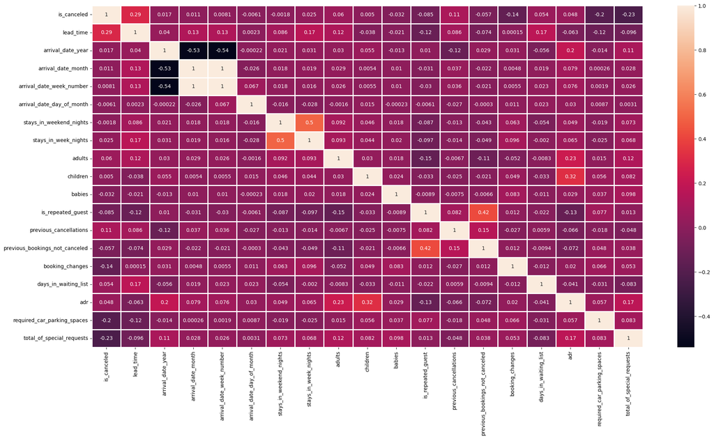

```python
#numeric columns for correlation
numeric_df = df.select_dtypes(include=['number'])

#correlation matrix
corr = numeric_df.corr()

# Create a heatmap of the correlation matrix
plt.figure(figsize=(24, 12))
sns.heatmap(corr, annot=True, linewidths=1)
plt.show()
```

```python
df['is_cancelled'] = df['reservation_status'].apply(lambda x: 1 if x == 'Canceled' else 0)

# Calculate the correlation
print("Correlation between ADR and cancellation:", df['adr'].corr(df['is_cancelled']))
```

```
Correlation between ADR and cancellation: 0.0501087305615969
```

However, from this correlation heatmap, its clear that there is at least some positive correlation between previous bookings being cancelled, and whether or not the customer is a repeated guest or not. This is most likely because there cannot a previous booking that is cancelled unless the customer themselves is a repeated guest. Otherwise the answer is always false.

```python
X = sm.add_constant(df['adr'])  # adding a constant
model = sm.Logit(df['is_cancelled'], X)
result = model.fit()
print(result.summary())
```

```
Optimization terminated successfully.
         Current function value: 0.652277
         Iterations 4
                           Logit Regression Results
==============================================================================
Dep. Variable:           is_cancelled   No. Observations:               119390
Model:                          Logit   Df Residuals:                   119388
Method:                           MLE   Df Model:                            1
Date:                Wed, 08 May 2024   Pseudo R-squ.:                0.002015
Time:                        03:35:10   Log-Likelihood:                -77875.
converged:                       True   LL-Null:                       -78033.
Covariance Type:            nonrobust   LLR p-value:                 2.270e-70
==============================================================================
                 coef    std err          z      P>|z|      [0.025      0.975]
------------------------------------------------------------------------------
const         -0.7993      0.014    -56.483      0.000      -0.827      -0.772
adr            0.0022      0.000     17.706      0.000       0.002       0.002
==============================================================================
```

```python
correlation, p_value = pointbiserialr(df['is_cancelled'], df['adr'])

# Step 4: Compare p-value with α
alpha = 0.05
if p_value < alpha:
    print("Reject the null hypothesis. There is a significant correlation between 'is_cancelled' and 'adr'.")
else:
    print("Fail to reject the null hypothesis. There is no significant correlation between 'is_cancelled' and 'adr'.")

# Step 5: Print the results
print("Point-Biserial Correlation Coefficient:", correlation)
print("P-value:", p_value)
```

```
Reject the null hypothesis. There is a significant correlation between 'is_cancelled' and 'adr'.
Point-Biserial Correlation Coefficient: 0.05010873056159629
P-value: 3.0628669376702576e-67
```

Notice anything different, the information looks about the same, but we have a P-value of 0. What does that mean? Skim through this article:

https://www.investopedia.com/terms/p/p-value.asp#:~:text=A%20p%2Dvalue%20measures%20the,is%20generally%20considered%20statistically%20significant.

From this we can tell that a P-value near 0 seems to indicate that what we are observing is not random or conicenede: rather, that it is a small, weak correlation, but one that is most deifintely related in nature, not random. That is to say: price likely related to a small increase in calculations. Is there any way we can check whether this is something that tracks historically?

```
market_segment
Online TA        56477
Offline TA/TO    24219
Groups           19811
Direct           12606
Corporate         5295
Complementary      743
Aviation           237
Undefined            2
Name: count, dtype: int64
```

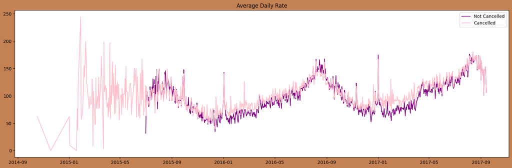

```python
print(df['market_segment'].value_counts())
cancelled_data = df
cancelled_data['market_segment'].value_counts(normalize=True)


cancelled_df_adr= cancelled_data.groupby('reservation_status_date')[['adr']].mean()
cancelled_df_adr.reset_index(inplace=True)
cancelled_df_adr.sort_values('reservation_status_date', inplace=True)

not_cancelled_data=df[df['is_cancelled']==0]
not_cancelled_df_adr= not_cancelled_data.groupby('reservation_status_date')[['adr']].mean()
not_cancelled_df_adr.reset_index(inplace=True)
not_cancelled_df_adr.sort_values('reservation_status_date', inplace=True)

plt.figure(figsize=(20, 6), facecolor='#C38154')
plt.title('Average Daily Rate', color="Black")

# Plotting not cancelled data in purple
plt.plot(not_cancelled_df_adr['reservation_status_date'], not_cancelled_df_adr['adr'], label='Not Cancelled', color='purple')

# Plotting cancelled data in pink
plt.plot(cancelled_df_adr['reservation_status_date'], cancelled_df_adr['adr'], label='Cancelled', color='pink')

plt.legend()
plt.show()
```

Everyone knows the hassle of booking a vacation during the holidays. Once summer kicks in, or you need to make a thankgsviing dinner, or a christmas family reunion, things can get hectic: seasonality is a critical part of the value-prop for a hotel: you get to enjoy the best times in the best places, and hotels facilitate that. Let's see if some months are more likely to see cancellations/irregular activity than others.

Let's start by seeing how many reservations there are per-month.

```python
monthly_cancellation_counts = df.groupby(['arrival_date_month', 'is_canceled']).size().unstack(fill_value=0)

# Rename columns f
monthly_cancellation_counts.columns = ['not_cancelled', 'cancelled']

# Reset index
monthly_cancellation_counts.reset_index(inplace=True)

#  sort by 'arrival_date_month
monthly_cancellation_counts.sort_values('arrival_date_month', inplace=True)

print(monthly_cancellation_counts)
```

```
    arrival_date_month  not_cancelled  cancelled
0                    1           4122       1807
1                    2           5372       2696
2                    3           6645       3149
3                    4           6565       4524
4                    5           7114       4677
5                    6           6404       4535
6                    7           7919       4742
7                    8           8638       5239
8                    9           6392       4116
9                   10           6914       4246
10                  11           4672       2122
11                  12           4409       2371
```

As we previously converted before, instead of seeing "january-december", we see 1-12: should be asy enough to understand.

What can we tell about the data from here? It's hard to tell actual proportions, but it's clear some months receive more business than others. In order to see trends over time between cancellations and non-cancellations, a bar graph ordered from january to december left-right can help us quickly asess any obvious patterns.

Let's graph this

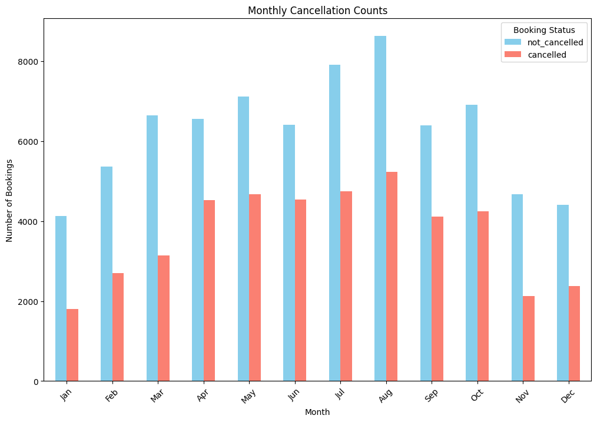

```python
fig, ax = plt.subplots(figsize=(12, 8))
monthly_cancellation_counts.plot(kind='bar', x='arrival_date_month', y=['not_cancelled', 'cancelled'], ax=ax, color=['skyblue', 'salmon'])
ax.set_title('Monthly Cancellation Counts')
ax.set_xlabel('Month')
ax.set_ylabel('Number of Bookings')
ax.set_xticklabels(['Jan', 'Feb', 'Mar', 'Apr', 'May', 'Jun', 'Jul', 'Aug', 'Sep', 'Oct', 'Nov', 'Dec'], rotation=45)
plt.legend(title='Booking Status')
plt.show()
```

It's a little supribing that November - January does not see that many bookings: although it makes sense that the summer would see the most amonut of bookings, as that is when everybody is free. Still though, it's hard to if cancellations are actually up in certain months, or whether business in general is up. Let's make a better bar graph that fit's our goal better: each month's cancellation rate.

```python
monthly_cancellation_counts['total_bookings'] = monthly_cancellation_counts['not_cancelled'] + monthly_cancellation_counts['cancelled']

# percentage of cancellations
monthly_cancellation_counts['cancellation_percentage'] = (monthly_cancellation_counts['cancelled'] / monthly_cancellation_counts['total_bookings']) * 100

# new datafram
print(monthly_cancellation_counts[['arrival_date_month', 'cancellation_percentage']])
```

```
    arrival_date_month  cancellation_percentage
0                    1                30.477315
1                    2                33.415964
2                    3                32.152338
3                    4                40.797186
4                    5                39.665847
5                    6                41.457172
6                    7                37.453598
7                    8                37.753117
8                    9                39.170156
9                   10                38.046595
10                  11                31.233441
11                  12                34.970501
```

By dividing the cancelled category's "yes" value -1 by the total bookings, we can see what percentage of bookings actually got cancelled. It seems like there is a significant dispartity between each month! let's graph this data as well.

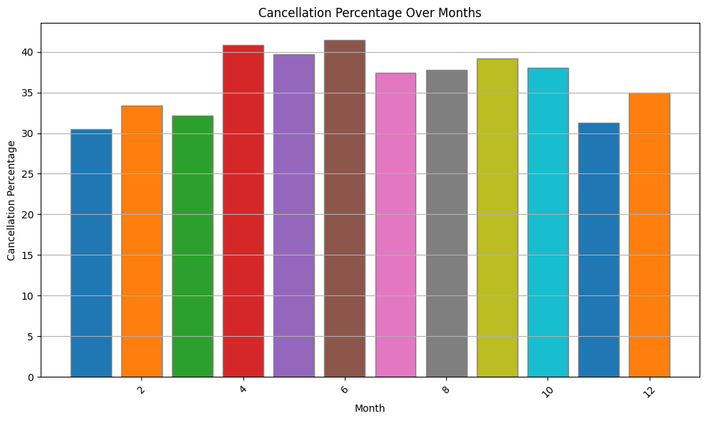

```python
basic_colors = ['#1f77b4', '#ff7f0e', '#2ca02c', '#d62728', '#9467bd', '#8c564b', '#e377c2', '#7f7f7f', '#bcbd22', '#17becf']

plt.figure(figsize=(10, 6))
bars = plt.bar(monthly_cancellation_counts['arrival_date_month'],
               monthly_cancellation_counts['cancellation_percentage'],
               color=basic_colors)
plt.title('Cancellation Percentage Over Months')
plt.xlabel('Month')
plt.ylabel('Cancellation Percentage')
plt.xticks(rotation=45)

# Set edgecolor for solid bars
for bar in bars:
    bar.set_edgecolor('grey')

plt.grid(axis='y')
plt.tight_layout()
plt.show()
```

We'll use Levene's test to examine the potential interplay between months, booking changes, and cancellations. The reason we are comparing booking changes is to try and see seasonality/season volatility, when many people are hecticly planning and things change. This can introduce volatility and irregularties in our dataset, that if somehwat ordered, we may need to structure our models around. This analysis aims to determine if these factors are actually connected. While prices might independently influence cancellations, we're interested in discerning if seasonality or holiday volatility plays a role. If Levene's test reveals significant associations among months, booking changes, and cancellations, it suggests a unique insight into how hotel managers can strategize for specific time periods.

```python
stat_adr, p_adr = levene(*[group['adr'] for name, group in df.groupby('arrival_date_month')])
print('Levene’s test for adr (Statistic: {:.3f}, P-value: {:.3f})'.format(stat_adr, p_adr))

# Levene's test for equality of variances in booking_changes
stat_bc, p_bc = levene(*[group['booking_changes'] for name, group in df.groupby('arrival_date_month')])
print('Levene’s test for booking changes (Statistic: {:.3f}, P-value: {:.3f})'.format(stat_bc, p_bc))

# Decision based on Levene's test
if p_adr > 0.05 and p_bc > 0.05:
    print("Variances are equal across groups. Proceed with ANOVA.")
else:
    print("Variances are not equal. Consider using transformations or non-parametric tests.")
```

```
Levene’s test for adr (Statistic: 683.338, P-value: 0.000)
Levene’s test for booking changes (Statistic: 13.661, P-value: 0.000)
Variances are not equal. Consider using transformations or non-parametric tests.
```

Looks like thay have statiscally notable unequal variance levels, suggesting that their variances might be less prone to comparison. Therefore, it's likely theyour models should account for different levels of variance.

As I mentioned previously my uncle in India always faced a huge headache when it cames to cancellations in Goa-due to enviormental/societal factors which unforunately arent really represented in our dataset. However, we can still see if certain countries have cancellations alot more than others. Countries are inherently a global value that should be taken in the context of the world. So let's make a map out of them using the Geopandas library! Documentation below, but this is pretty basic so feel free to follow along.

https://geopandas.org/en/stable/docs/user_guide/mapping.html

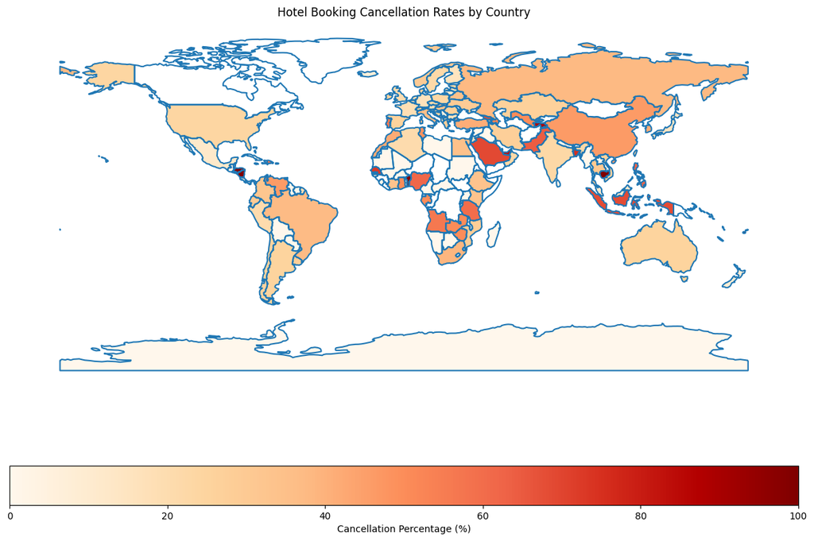

```python
country_df = pd.read_csv('hotel_bookings.csv')
country_stats = country_df.groupby('country').agg(
    total_bookings=('is_canceled', 'count'),
    cancellations=('is_canceled', 'sum')
)

# cancellation percentage
country_stats['cancellation_percentage'] = (country_stats['cancellations'] / country_stats['total_bookings']) * 100

# Reset the index
country_cancellations = country_stats.reset_index()[['country', 'cancellation_percentage']]
pd.set_option('display.max_rows', None)  # This will allow all rows to be displayed

# Print the entire DataFrame


world = gpd.read_file(gpd.datasets.get_path('naturalearth_lowres'))
world = world[['iso_a3', 'geometry']]
world = world.merge(country_cancellations, left_on='iso_a3', right_on='country', how='left')


fig, ax = plt.subplots(1, 1, figsize=(15, 10))

# Plot the world with countries colored by cancellation percentage
world.boundary.plot(ax=ax)
world.plot(column='cancellation_percentage', ax=ax, legend=True,
           legend_kwds={'label': "Cancellation Percentage (%)",
                        'orientation': "horizontal"},
           cmap='OrRd')  # Color map can be changed as needed

# Add a title and remove axes
ax.set_title('Hotel Booking Cancellation Rates by Country')
ax.set_axis_off()

# Show the plot
plt.show()
```

```python
saudi_bookings_count = df[df['country'] == 'SAU'].shape[0]

# total number of bookings
print(f"Total bookings from Saudi Arabia: {saudi_bookings_count}")
```

```
Total bookings from Saudi Arabia: 48
```

Let's look at the general distribution, and see how far down the list of countires we can get until we get to small numbers that cant really impact our dataset or just might be too small to actually calculate in any significant way.

```python
# Assuming 'df' is your DataFrame containing the dataset
country_counts = df['country'].value_counts()

# Print the top 20 country counts
print(country_counts.head(30))
```

```
country
PRT    48590
GBR    12129
FRA    10415
ESP     8568
DEU     7287
ITA     3766
IRL     3375
BEL     2342
BRA     2224
NLD     2104
USA     2097
CHE     1730
CN      1279
AUT     1263
SWE     1024
CHN      999
POL      919
ISR      669
RUS      632
NOR      607
ROU      500
FIN      447
DNK      435
AUS      426
AGO      362
LUX      287
MAR      259
TUR      248
HUN      230
ARG      214
Name: count, dtype: int64
```

These 30 entries represnt about 97% of the dataset, and any values smaller than this are not enough to many substantial claims about the dataset. Let's leave them for now

Now, let's print out the top cancellation percentages for each of these conutires and order them accordingly.

```python
country_df = pd.read_csv('hotel_bookings.csv')

# Group by country and aggregate the data
country_stats = country_df.groupby('country').agg(
    total_bookings=('is_canceled', 'count'),
    cancellations=('is_canceled', 'sum')
)

# Calculate cancellation percentage
country_stats['cancellation_percentage'] = (country_stats['cancellations'] / country_stats['total_bookings']) * 100

# Reset the index to make 'country' a column
country_cancellations = country_stats.reset_index()[['country', 'cancellation_percentage', 'total_bookings']]

# Apply the filter for countries with fewer than 200 entries
country_cancellations = country_cancellations[country_cancellations['total_bookings'] > 200]

# Sort the DataFrame by cancellation percentage in descending order
country_cancellations = country_cancellations.sort_values(by='cancellation_percentage', ascending=False)

# Set display option to show all rows
pd.set_option('display.max_rows', None)

# Print the DataFrame
print(country_cancellations)
```

```
    country  cancellation_percentage  total_bookings
135     PRT                56.635110           48590
1       AGO                56.629834             362
31      CHN                46.246246             999
103     MAR                42.084942             259
162     TUR                41.129032             248
100     LUX                37.979094             287
140     RUS                37.816456             632
25      BRA                37.320144            2224
81      ITA                35.395645            3766
72      HUN                33.478261             230
124     NOR                29.818781             607
139     ROU                26.800000             500
51      ESP                25.408497            8568
80      ISR                25.261584             669
```

[output cut: 16 more lines]

WOW! Portugal makes up a good third of our data, and yet it also has the highest cancellation rate amongst represented countries??? We need to explore that!

Does portugals average heavily differ from the rest of the world?

```python
prt_data = df[df['country'] == 'PRT']
prt_cancellation_rate = prt_data['is_canceled'].mean() * 100  # Convert to percentage

# Calculate the cancellation rate for all countries except PRT
non_prt_data = df[df['country'] != 'PRT']
non_prt_cancellation_rate = non_prt_data['is_canceled'].mean() * 100  # Convert to percentage

# Print the results
print(f"Average cancellation rate for Portugal (PRT): {prt_cancellation_rate:.2f}%")
print(f"Average cancellation rate for all other countries: {non_prt_cancellation_rate:.2f}%")
```

```
Average cancellation rate for Portugal (PRT): 56.64%
Average cancellation rate for all other countries: 23.59%
```

Looks like it does, and by a huge margin. However, just checking these numbers is not enough. Let's do a chi-quare test to see if there is in general a correlation between countries and cancellations.

Why do a Chi-Square test?

A chi-square test is the test of choice for seeing whether one variable relates to changes in another variable, specfically it can help idenfity if some changes are due to change or if they are due to just happenstance.

As a quick intutiive way to udnerstand it, it measure the difference between if we observed the frequencies of data assuming the variables were related, contrasted to if we observe the data assuming there is NO correlation. Here is a short youtube video that gets the point across:

https://www.youtube.com/watch?v=7_cs1YlZoug

```python
contingency_table = pd.crosstab(df['country'], df['is_canceled'])

# Perform the chi-square test
chi2, p_value, dof, expected = chi2_contingency(contingency_table)

# Print the results
print(f"Chi-square statistic: {chi2}")
print(f"P-value: {p_value}")
```

```
Chi-square statistic: 15434.681532788674
P-value: 0.0
```

Let's look at the numbers: that number in speicifc is huge: it reprsents teh difference between no-correlation ie assuming correlation: meaning for our suggestion that country andd cancellations are related, this is a great indicator. But how do we know whether this is by chance or not?

Seems like the answer is OVERWHELIMINGLY YES. Now, let's check out if Portugal in specific is an indicator of a possible cancellation.

```python
# Counts of cancellations
count_prt = prt_data['is_canceled'].sum()
count_non_prt = non_prt_data['is_canceled'].sum()

# Number of observations
nobs_prt = prt_data['is_canceled'].count()
nobs_non_prt = non_prt_data['is_canceled'].count()

# Z-test for two proportions
stat, pval = proportions_ztest([count_prt, count_non_prt], [nobs_prt, nobs_non_prt])

# Print the results
print(f"Z-statistic: {stat}")
print(f"P-value: {pval}")
```

```
Z-statistic: 116.13968316796154
P-value: 0.0
```

The answer here also again looks like overwhelmingly yes. Countries play a big part in determining whether or not a cancellation happens or not.

# Primary Analysis / Data Processing for ML Models

Now that we know a couple of important things about the dataset, let's get to work on building our machine learning models, which will be able to decide for themsleves whether a data entry was cancelled or not without actually seeing the column: this way, we can predict in the future whether to make a reservation or not, and save my uncle some time 🙏.

A quick thing I want to adress before we get into this: this dataset can be interpreted in many ways but it is at it's core a classification problem. However, there are many ways we can go about classifying the dataset, and I believe doing. a good share of them will help us best determine what the answer to this common problem is.

These data points are either hard to work with or dont really tell us much about the data: the year does not really matter since we cant predict the underlying factors that would make one year different from another. Aditionally, we already have core pieces of information that are both varied and correlated strong enough that we dont necesarily need to get into the weeds about tough data to crunch, like days in a waiting list. What if theres more of a waiting list during the holidays? Booking changes? How were they counted in each instance? These data values are prone to changes that we cannot have real answers for, so we are just going to drop them

```python
df.drop('assigned_room_type', axis=1, inplace=True)
df.drop('booking_changes', axis=1, inplace=True)
df.drop('reservation_status', axis=1, inplace=True)
df.drop('days_in_waiting_list', axis=1, inplace=True)
df.drop('arrival_date_year', axis=1, inplace=True)
```

Let's get a quick overview of what the dataframe looks like now.

```python
df.head()
```

|  | hotel | is_canceled | lead_time | arrival_date_month | arrival_date_week_number | arrival_date_day_of_month | stays_in_weekend_nights | stays_in_week_nights | adults | children | ... | previous_cancellations | previous_bookings_not_canceled | reserved_room_type | deposit_type | customer_type | adr | required_car_parking_spaces | total_of_special_requests | reservation_status_date | is_cancelled |
| --- | --- | --- | --- | --- | --- | --- | --- | --- | --- | --- | --- | --- | --- | --- | --- | --- | --- | --- | --- | --- | --- |
| 0 | Resort Hotel | 0 | 342 | 7 | 27 | 1 | 0 | 0 | 2 | 0.0 | ... | 0 | 0 | C | No Deposit | Transient | 0.0 | 0 | 0 | 2015-07-01 | 0 |
| 1 | Resort Hotel | 0 | 737 | 7 | 27 | 1 | 0 | 0 | 2 | 0.0 | ... | 0 | 0 | C | No Deposit | Transient | 0.0 | 0 | 0 | 2015-07-01 | 0 |
| 2 | Resort Hotel | 0 | 7 | 7 | 27 | 1 | 0 | 1 | 1 | 0.0 | ... | 0 | 0 | A | No Deposit | Transient | 75.0 | 0 | 0 | 2015-07-02 | 0 |
| 3 | Resort Hotel | 0 | 13 | 7 | 27 | 1 | 0 | 1 | 1 | 0.0 | ... | 0 | 0 | A | No Deposit | Transient | 75.0 | 0 | 0 | 2015-07-02 | 0 |
| 4 | Resort Hotel | 0 | 14 | 7 | 27 | 1 | 0 | 2 | 2 | 0.0 | ... | 0 | 0 | A | No Deposit | Transient | 98.0 | 0 | 1 | 2015-07-03 | 0 |

5 rows × 26 columns

If you remember from the beggining of this tutorial, we modified the months to be taken as 1-12 instead of Jan-Dec. In that same vein, we are going to convert alot of these values into integers so that the model is better able to handle them. Let's write a function which grabs all the non-numeric categories and stores them in a variable for easy processing.

```python
string_cols = [col for col in df.columns if df[col].dtype == 'O']
string_cols
string_df = df[string_cols]
for col in string_df.columns:
    print(f"{col}: \n{string_df[col].unique()}\n")
```

```
hotel:
['Resort Hotel' 'City Hotel']

meal:
['BB' 'FB' 'HB' 'SC' 'Undefined']

country:
['PRT' 'GBR' 'USA' 'ESP' 'IRL' 'FRA' nan 'ROU' 'NOR' 'OMN' 'ARG' 'POL'
 'DEU' 'BEL' 'CHE' 'CN' 'GRC' 'ITA' 'NLD' 'DNK' 'RUS' 'SWE' 'AUS' 'EST'
 'CZE' 'BRA' 'FIN' 'MOZ' 'BWA' 'LUX' 'SVN' 'ALB' 'IND' 'CHN' 'MEX' 'MAR'
 'UKR' 'SMR' 'LVA' 'PRI' 'SRB' 'CHL' 'AUT' 'BLR' 'LTU' 'TUR' 'ZAF' 'AGO'
 'ISR' 'CYM' 'ZMB' 'CPV' 'ZWE' 'DZA' 'KOR' 'CRI' 'HUN' 'ARE' 'TUN' 'JAM'
 'HRV' 'HKG' 'IRN' 'GEO' 'AND' 'GIB' 'URY' 'JEY' 'CAF' 'CYP' 'COL' 'GGY'
 'KWT' 'NGA' 'MDV' 'VEN' 'SVK' 'FJI' 'KAZ' 'PAK' 'IDN' 'LBN' 'PHL' 'SEN'
 'SYC' 'AZE' 'BHR' 'NZL' 'THA' 'DOM' 'MKD' 'MYS' 'ARM' 'JPN' 'LKA' 'CUB'
 'CMR' 'BIH' 'MUS' 'COM' 'SUR' 'UGA' 'BGR' 'CIV' 'JOR' 'SYR' 'SGP' 'BDI'
 'SAU' 'VNM' 'PLW' 'QAT' 'EGY' 'PER' 'MLT' 'MWI' 'ECU' 'MDG' 'ISL' 'UZB'
 'NPL' 'BHS' 'MAC' 'TGO' 'TWN' 'DJI' 'STP' 'KNA' 'ETH' 'IRQ' 'HND' 'RWA'
 'KHM' 'MCO' 'BGD' 'IMN' 'TJK' 'NIC' 'BEN' 'VGB' 'TZA' 'GAB' 'GHA' 'TMP'
 'GLP' 'KEN' 'LIE' 'GNB' 'MNE' 'UMI' 'MYT' 'FRO' 'MMR' 'PAN' 'BFA' 'LBY'
 'MLI' 'NAM' 'BOL' 'PRY' 'BRB' 'ABW' 'AIA' 'SLV' 'DMA' 'PYF' 'GUY' 'LCA'
 'ATA' 'GTM' 'ASM' 'MRT' 'NCL' 'KIR' 'SDN' 'ATF' 'SLE' 'LAO']

market_segment:
['Direct' 'Corporate' 'Online TA' 'Offline TA/TO' 'Complementary' 'Groups'
 'Undefined' 'Aviation']

distribution_channel:
['Direct' 'Corporate' 'TA/TO' 'Undefined' 'GDS']

reserved_room_type:
['C' 'A' 'D' 'E' 'G' 'F' 'H' 'L' 'P' 'B']

deposit_type:
['No Deposit' 'Refundable' 'Non Refund']

customer_type:
['Transient' 'Contract' 'Transient-Party' 'Group']
```

Now, let's convert these into integers with similar for-loop logic for model-readability.

```python
label_encoders = {}
encoded_string_df = string_df.copy()

for col in string_df.columns:
    label_encoders[col] = LabelEncoder()
    encoded_string_df[col] = label_encoders[col].fit_transform(string_df[col])

# Display the encoded values
for col in encoded_string_df.columns:
    print(f"{col}: \n{encoded_string_df[col].unique()}\n")
```

```
hotel:
[1 0]

meal:
[0 1 2 3 4]

country:
[135  59 169  51  76  56 177 139 124 127   6 133  43  15  29  34  66  81
 123  46 140 154  11  52  42  25  54 113  27 100 153   3  75  31 107 103
 166 148 101 134 149  30  12  23  99 162 174   1  80  40 175  37 176  48
  91  38  72   5 161  82  71  69  77  60   4  63 168  83  28  41  35  61
  92 121 106 171 152  55  86 128  73  94 131 144 155  13  20 126 158  47
 108 117   7  85  98  39  33  22 115  36 151 165  19  32  84 156 145  14
 142 173 132 138  50 130 110 116  49 105  79 170 125  21 102 157 163  44
 150  90  53  78  70 141  88 104  18  74 159 122  16 172 164  58  62 160
  64  87  97  65 112 167 118  57 111 129  17  95 109 119  24 136  26   0
   2 147  45 137  68  96   9  67   8 114 120  89 143  10 146  93]

market_segment:
[3 2 6 5 1 4 7 0]

distribution_channel:
[1 0 3 4 2]

reserved_room_type:
[2 0 3 4 6 5 7 8 9 1]

deposit_type:
[0 2 1]

customer_type:
[2 0 3 1]
```

Let's make sure everything is in order again.

```python
encoded_string_df.head()
```

|  | hotel | meal | country | market_segment | distribution_channel | reserved_room_type | deposit_type | customer_type |
| --- | --- | --- | --- | --- | --- | --- | --- | --- |
| 0 | 1 | 0 | 135 | 3 | 1 | 2 | 0 | 2 |
| 1 | 1 | 0 | 135 | 3 | 1 | 2 | 0 | 2 |
| 2 | 1 | 0 | 59 | 3 | 1 | 0 | 0 | 2 |
| 3 | 1 | 0 | 59 | 2 | 0 | 0 | 0 | 2 |
| 4 | 1 | 0 | 59 | 6 | 3 | 0 | 0 | 2 |

Because we handled all of these in a new variable which stores non-categorical variables let's drop these as well and now check if the dataframe is properly absent of said values.

```python
df.drop('hotel', axis=1, inplace=True)
df.drop('meal', axis=1, inplace=True)
df.drop('market_segment', axis=1, inplace=True)
df.drop('distribution_channel', axis=1, inplace=True)
df.drop('reserved_room_type', axis=1, inplace=True)
df.drop('deposit_type', axis=1, inplace=True)
df.drop('customer_type', axis=1, inplace=True)
df.drop(['country'], axis=1, inplace=True)
df.head()
```

|  | is_canceled | lead_time | arrival_date_month | arrival_date_week_number | arrival_date_day_of_month | stays_in_weekend_nights | stays_in_week_nights | adults | children | babies | is_repeated_guest | previous_cancellations | previous_bookings_not_canceled | adr | required_car_parking_spaces | total_of_special_requests | reservation_status_date | is_cancelled |
| --- | --- | --- | --- | --- | --- | --- | --- | --- | --- | --- | --- | --- | --- | --- | --- | --- | --- | --- |
| 0 | 0 | 342 | 7 | 27 | 1 | 0 | 0 | 2 | 0.0 | 0 | 0 | 0 | 0 | 0.0 | 0 | 0 | 2015-07-01 | 0 |
| 1 | 0 | 737 | 7 | 27 | 1 | 0 | 0 | 2 | 0.0 | 0 | 0 | 0 | 0 | 0.0 | 0 | 0 | 2015-07-01 | 0 |
| 2 | 0 | 7 | 7 | 27 | 1 | 0 | 1 | 1 | 0.0 | 0 | 0 | 0 | 0 | 75.0 | 0 | 0 | 2015-07-02 | 0 |
| 3 | 0 | 13 | 7 | 27 | 1 | 0 | 1 | 1 | 0.0 | 0 | 0 | 0 | 0 | 75.0 | 0 | 0 | 2015-07-02 | 0 |
| 4 | 0 | 14 | 7 | 27 | 1 | 0 | 2 | 2 | 0.0 | 0 | 0 | 0 | 0 | 98.0 | 0 | 1 | 2015-07-03 | 0 |

Look's great! Finally, we need a "answer" column to compare our Testing data do. Let's generate a variable which holds a column that as you go down for each index, will tell you the "answer" for that index-whether it was actually a cancelled reservation or not. THIS NEXT STEP IS CRUCIAL AND IS OFTEN FORGOT:

Make sure to actually delete the is_cancelled from your training set! Otherwise, the model doesnt have to guess anything: it will eventually realize it has this super conveinent value which happens to be 100% accurate all the time is a better indicator than actually processing and modifying weights, regression or doing anything cool it will just overfit and spit out that value.

```python
y = df['is_cancelled']
df = df.drop(['is_cancelled'], axis=1)
combined_set = pd.concat([encoded_string_df, df], axis = 1)
X = pd.concat([encoded_string_df, df], axis = 1)
```

Now, we can use the train_test_split function to be able to generate training data, testing data, training answers, and testing answers for which all our models will be based on and use to create their answers.

```python
X_train, X_test, y_train, y_test = train_test_split(X, y, test_size = 0.20)
```

Let's look at one of these! Looks just like a regular dataframe.

```python
X_train.head()
```

|  | hotel | meal | country | market_segment | distribution_channel | reserved_room_type | deposit_type | customer_type | is_canceled | lead_time | ... | adults | children | babies | is_repeated_guest | previous_cancellations | previous_bookings_not_canceled | adr | required_car_parking_spaces | total_of_special_requests | reservation_status_date |
| --- | --- | --- | --- | --- | --- | --- | --- | --- | --- | --- | --- | --- | --- | --- | --- | --- | --- | --- | --- | --- | --- |
| 67081 | 0 | 0 | 43 | 6 | 3 | 0 | 0 | 2 | 1 | 153 | ... | 2 | 0.0 | 0 | 0 | 0 | 0 | 117.00 | 0 | 1 | 2017-01-17 |
| 60353 | 0 | 0 | 135 | 4 | 3 | 0 | 1 | 2 | 1 | 277 | ... | 2 | 0.0 | 0 | 0 | 0 | 0 | 100.00 | 0 | 0 | 2016-04-04 |
| 53110 | 0 | 2 | 135 | 5 | 3 | 0 | 0 | 3 | 1 | 256 | ... | 2 | 0.0 | 0 | 0 | 0 | 0 | 109.00 | 0 | 0 | 2016-06-08 |
| 110373 | 0 | 0 | 43 | 5 | 3 | 0 | 0 | 3 | 0 | 310 | ... | 2 | 0.0 | 0 | 0 | 0 | 0 | 83.75 | 0 | 0 | 2017-04-27 |
| 2814 | 1 | 0 | 135 | 4 | 1 | 0 | 1 | 2 | 1 | 155 | ... | 2 | 0.0 | 0 | 0 | 0 | 0 | 36.00 | 0 | 0 | 2015-10-26 |

5 rows × 25 columns

```python
X_test.head()
```

|  | hotel | meal | country | market_segment | distribution_channel | reserved_room_type | deposit_type | customer_type | is_canceled | lead_time | ... | adults | children | babies | is_repeated_guest | previous_cancellations | previous_bookings_not_canceled | adr | required_car_parking_spaces | total_of_special_requests | reservation_status_date |
| --- | --- | --- | --- | --- | --- | --- | --- | --- | --- | --- | --- | --- | --- | --- | --- | --- | --- | --- | --- | --- | --- |
| 110900 | 0 | 3 | 169 | 5 | 2 | 4 | 0 | 2 | 0 | 0 | ... | 1 | 0.0 | 0 | 0 | 0 | 0 | 190.0 | 0 | 1 | 2017-05-04 |
| 22199 | 1 | 0 | 51 | 5 | 3 | 0 | 0 | 2 | 0 | 2 | ... | 2 | 0.0 | 0 | 0 | 0 | 0 | 29.0 | 0 | 1 | 2016-03-20 |
| 75858 | 0 | 0 | 135 | 4 | 3 | 0 | 0 | 3 | 1 | 351 | ... | 2 | 0.0 | 0 | 0 | 1 | 0 | 62.0 | 0 | 0 | 2015-07-06 |
| 98991 | 0 | 0 | 59 | 6 | 3 | 0 | 0 | 2 | 0 | 29 | ... | 2 | 0.0 | 0 | 0 | 0 | 0 | 152.0 | 0 | 2 | 2016-10-07 |
| 36665 | 1 | 0 | 43 | 6 | 3 | 4 | 0 | 2 | 0 | 221 | ... | 2 | 0.0 | 0 | 0 | 0 | 0 | 103.5 | 1 | 2 | 2017-05-25 |

5 rows × 25 columns

```python
y_test.head()
```

```
110900    0
22199     0
75858     1
98991     0
36665     0
Name: is_cancelled, dtype: int64
```

```python
y_train.head()
```

```
67081     1
60353     1
53110     1
110373    0
2814      1
Name: is_cancelled, dtype: int64
```

```python
X_train['year'] = X_train['reservation_status_date'].dt.year
X_train['month'] = X_train['reservation_status_date'].dt.month
X_train['day'] = X_train['reservation_status_date'].dt.day

# additional features
X_train['day_of_week'] = X_train['reservation_status_date'].dt.dayofweek
X_train['is_weekend'] = (X_train['reservation_status_date'].dt.weekday >= 5).astype(int)

# Drop the original datetime
X_train = X_train.drop(columns=['reservation_status_date'])

nan_rows_count = X_train.isna().any(axis=1).sum()
X_train = X_train.dropna()
y_train = y_train[X_train.index]


X_test['year'] = X_test['reservation_status_date'].dt.year
X_test['month'] = X_test['reservation_status_date'].dt.month
X_test['day'] = X_test['reservation_status_date'].dt.day


X_test['day_of_week'] = X_test['reservation_status_date'].dt.dayofweek
X_test['is_weekend'] = (X_test['reservation_status_date'].dt.weekday >= 5).astype(int)


X_test = X_test.drop(columns=['reservation_status_date'])

# Check for NaN values
nan_rows_count_test = X_test.isna().any(axis=1).sum()
print(f"Number of rows with any NaN values in test set: {nan_rows_count_test}")

# Drop rows with any NaN values
X_test = X_test.dropna()

# Ensure y_test is aligned by dropping corresponding indices
y_test = y_test[X_test.index]
```

```
Number of rows with any NaN values in test set: 0
```

Let's make sure the answer sets look good

```python
y_train.head()
```

```
67081     1
60353     1
53110     1
110373    0
2814      1
Name: is_cancelled, dtype: int64
```

```python
y_test.head()
```

```
110900    0
22199     0
75858     1
98991     0
36665     0
Name: is_cancelled, dtype: int64
```

```python
nan_rows_count = X_train.isna().any(axis=1).sum()

print(f"Number of rows with any NaN values: {nan_rows_count}")
```

```
Number of rows with any NaN values: 0
```

YAY! No NaN values

# Model Development, Testing

Now it's time to actually develop out models and see how well they work. Luckily, we dont really have to do these from scratch, as the SKLearn library already has great implementations of these models that we can just use on the dataset we have curated.

You should be proud of yourself, we cleaned up the dataset and made sure it is compatible with these models: we have alot of power in our hands now.

Let's start with Logistic Regression. What is it? To keep it short, it works the way any of our equations in algebra do: we have a Dependent variable and then a certain amount of predictor variables that go into an equation to determine whether something can be classified one way or not. The way that this model trains, is that for every data point it makes a guess, and it tries to optimize its guess to be correct. It adjusts it's weights for predictor variables to try and be correct as much as possible. As such it's prone to overfitting since its literaly jsut adjusting to the numbers in a dataset. However, it's a good start.

I'll only repeat this once because the SKLearn Machine Learning models are prettty simple to use. Because we have done the dirty work of setting up and partitioning the data, all we have to dois just call.fit to fir the data/train it, and then .predict to predict for our entire test dataset. Then, we can compare our predictions to the actual values for the various metrics we want.

```python
logistic_model = LogisticRegression()
logistic_model.fit(X_train, y_train)

y_pred_lr = logistic_model.predict(X_test)

acc_lr = accuracy_score(y_test, y_pred_lr)
conf = confusion_matrix(y_test, y_pred_lr)
clf_report = classification_report(y_test, y_pred_lr)

print(f"Accuracy Score of Logistic Regression is : {acc_lr}")
print(f"Confusion Matrix : \n{conf}")
print(f"Classification Report : \n{clf_report}")
```

```
Accuracy Score of Logistic Regression is : 0.7882150933914063
Confusion Matrix :
[[13564  1713]
 [ 3344  5257]]
Classification Report :
              precision    recall  f1-score   support

           0       0.80      0.89      0.84     15277
           1       0.75      0.61      0.68      8601

    accuracy                           0.79     23878
   macro avg       0.78      0.75      0.76     23878
weighted avg       0.78      0.79      0.78     23878
```

Look's like our accuracy was around 80% for logistic regression. Let's break down each of these categories:

Now, we can analyze the confusion matrix to see how our data did. Did it classify cancel or no cancel, and oftentimes how write was it?

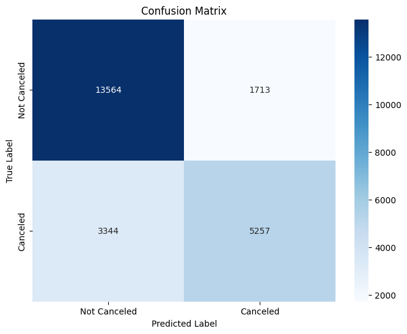

```python
conf_matrix = confusion_matrix(y_test, y_pred_lr)

# Plot the confusion matrix
plt.figure(figsize=(8, 6))
sns.heatmap(conf_matrix, annot=True, fmt='d', cmap='Blues', xticklabels=['Not Canceled', 'Canceled'], yticklabels=['Not Canceled', 'Canceled'])
plt.xlabel('Predicted Label')
plt.ylabel('True Label')
plt.title('Confusion Matrix')
plt.show()
```

It seems like when it comes to classfying true non-cancelled, our model is really good at it: but it's possible that false positive are still a problem: lets see if thats actually true:

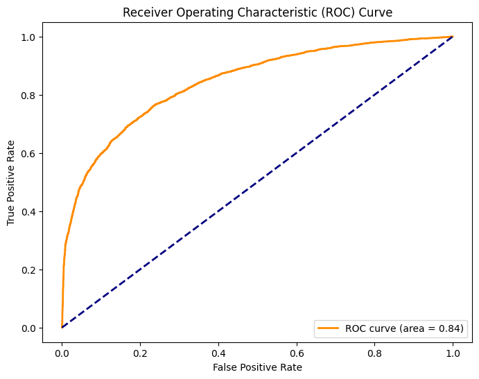

```python
y_probs_lr = logistic_model.predict_proba(X_test)[:, 1]

# Calculate ROC curve
fpr, tpr, thresholds = roc_curve(y_test, y_probs_lr)

# Plot ROC curve
plt.figure(figsize=(8, 6))
plt.plot(fpr, tpr, color='darkorange', lw=2, label=f'ROC curve (area = {roc_auc_score(y_test, y_probs_lr):.2f})')
plt.plot([0, 1], [0, 1], color='navy', lw=2, linestyle='--')
plt.xlabel('False Positive Rate')
plt.ylabel('True Positive Rate')
plt.title('Receiver Operating Characteristic (ROC) Curve')
plt.legend(loc="lower right")
plt.show()
#plot a certainty graph? plot the logistic graph itself
```

Now, let's take a look at a new type of Model: K Nearest Neighbors.

Let's imagine you can plot a point on a graph. Now imagine plotting a bunch of points on a graph. At a very basic level, the closer two points are, the more similar they are! It's with that same logic, that even if multiple 3d spaces, that we can plot points based on all their data and then check for the nearest neighborhs to see how similar they are. The K is the amount of neighbors we consdier: and we go with the majority class to classify it. Let's see what our scores look like:

```python
knn_model = KNeighborsClassifier()
knn_model.fit(X_train, y_train)

y_pred_knn = knn_model.predict(X_test)

acc_knn = accuracy_score(y_test, y_pred_knn)
conf = confusion_matrix(y_test, y_pred_knn)
clf_report = classification_report(y_test, y_pred_knn)
print(f"Accuracy Score of KNN is : {acc_knn}")
print(f"Confusion Matrix : \n{conf}")
print(f"Classification Report : \n{clf_report}")
```

```
Accuracy Score of KNN is : 0.8661110645782729
Confusion Matrix :
[[14432   845]
 [ 2352  6249]]
Classification Report :
              precision    recall  f1-score   support

           0       0.86      0.94      0.90     15277
           1       0.88      0.73      0.80      8601

    accuracy                           0.87     23878
   macro avg       0.87      0.84      0.85     23878
weighted avg       0.87      0.87      0.86     23878
```

Let;s use a heatmap like we did for the correlations earlier in the tutorial to show these values in a more readable way.

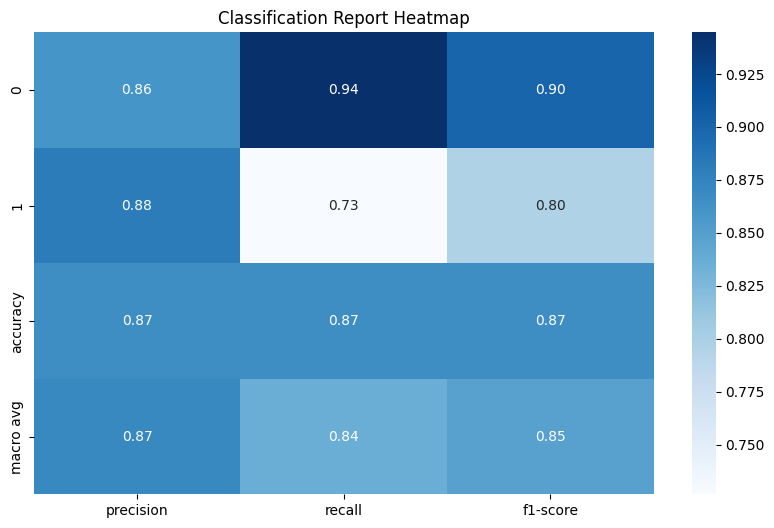

```python
report = classification_report(y_test, y_pred_knn, output_dict=True)

# Convert to DataFrame
report_df = pd.DataFrame(report).transpose()

# Drop the 'support' column if not needed
report_df.drop('support', axis=1, inplace=True)

# Plotting the classification report
plt.figure(figsize=(10, 6))
sns.heatmap(report_df.iloc[:-1, :].astype(float), annot=True, cmap="Blues", fmt=".2f")
plt.title('Classification Report Heatmap')
plt.show()
```

Whenever we want to classify thinks we often ask questions. For example, if I told you someone played a sports and you needed to figure out which sport, you would probably ask:

Are they tall?

Are they Slow? Are they Fast?

How much do they weight?

What's the strongest part of their body?

And as I answerwed these questions, you could be like "oh they are tall, fast, light, and their legs are strong, they probably play basketball!"

Or, you could be like:

"Oh they are short, slow, and their arms are strong. They must powerlift!".

This is how decision trees work. They organize the data by their most differentiating characteristivs, and move down a tree to eventually hit a end point where they have decided what classification they are. Here is a visual representation:

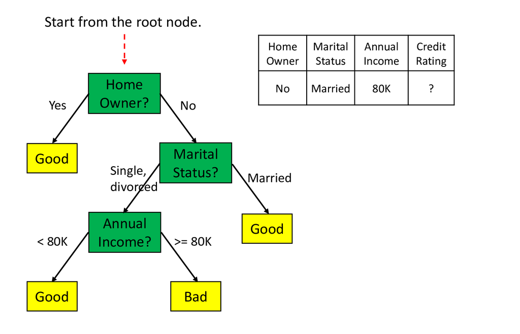

```python
features = [ 'lead_time','adults', 'is_repeated_guest', 'previous_cancellations', 'previous_bookings_not_canceled', 'adr',
             'total_of_special_requests', ]



X = df[features]
y = df['is_canceled']

nan_counts_features = X.isna().sum()
print("Number of NaNs in each feature column:")
print(nan_counts_features)

# Check for NaN values in the target variable
nan_count_target = y.isna().sum()
print("Number of NaNs in the target column ('is_canceled'):", nan_count_target)
```

```
Number of NaNs in each feature column:
lead_time                         0
adults                            0
is_repeated_guest                 0
previous_cancellations            0
previous_bookings_not_canceled    0
adr                               0
total_of_special_requests         0
dtype: int64
Number of NaNs in the target column ('is_canceled'): 0
```

```python
X = df[features]
y = df['is_canceled']

X_train, X_test, y_train, y_test = train_test_split(X, y, test_size=0.20, random_state=0)

dt_classifier = DecisionTreeClassifier(random_state=0, max_depth=10)

# Fit the model on the training data
dt_classifier.fit(X_train, y_train)



# Evaluate the model
train_score = dt_classifier.score(X_train, y_train)
test_score = dt_classifier.score(X_test, y_test)


print(f"Decision Tree Classifier on Training Data Accuracy: {train_score:.2f}")
print(f"Decision Tree Classifier on Test Data Accuracy: {test_score:.2f}")
```

```
Decision Tree Classifier on Training Data Accuracy: 0.76
Decision Tree Classifier on Test Data Accuracy: 0.75
```

Look's like our model is not as accurate as K nearest Neighborhs. This could be due to many factors. For example maybe we could benefit from bigger max-depth. Let's adjust that and see what happens.

```python
dt_classifier = DecisionTreeClassifier(random_state=0, max_depth=45)

# Fit the model on the training data
dt_classifier.fit(X_train, y_train)



# Evaluate the model
train_score = dt_classifier.score(X_train, y_train)
test_score = dt_classifier.score(X_test, y_test)


print(f"Decision Tree Classifier on Training Data Accuracy: {train_score:.2f}")
print(f"Decision Tree Classifier on Test Data Accuracy: {test_score:.2f}")
```

```
Decision Tree Classifier on Training Data Accuracy: 0.96
Decision Tree Classifier on Test Data Accuracy: 0.79
```

Looks like that improved things a little bit! With a 96% training accuracy, it seems as though the data is overfitting. However, theres also a increased accuracy on the test data by about 4%. However, since it's clear that this is mostly from overfitting and we dont want to depend on such a model, I will leave the iteration at that.

Let's take a look at what the decision tree looks like exactly:

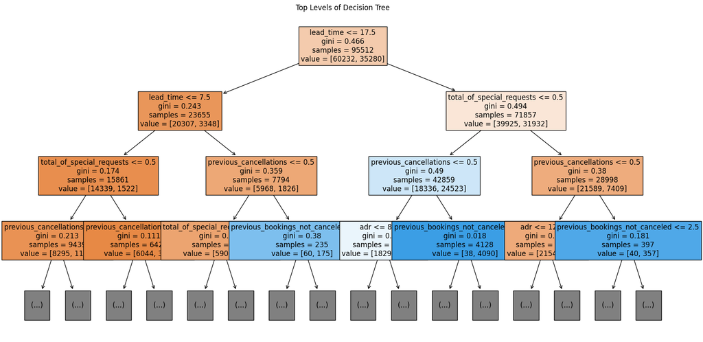

```python
plt.figure(figsize=(20, 10))
tree.plot_tree(dt_classifier, max_depth=3, filled=True, fontsize=12, feature_names=features)
plt.title('Top Levels of Decision Tree')
plt.show()
```

It looks like the decision tree is largely depdent on lead time to make most of it's decisions, and then onto special requests and previous cancellations. Intuitively, this makes sense: if they have cancelled before, that would be a pretty big indicator. If they have special requests, the chance they cancel might be affected because there is more effort being put into the reservation: either for better or worse. However, There are several reasons why this logic might be faulty: there are various parameters and conditions which might lead the tree down the wrong path, but contextually it would obviously infer something else. The performance of our tree is withheld because deicions are made outside of the context of each other: we need a model that considers everything more holistically.

```python
from sklearn.dummy import DummyClassifier
dummy = DummyClassifier(strategy='most_frequent')
dummy.fit(X_train, y_train)
dummy_score = dummy.score(X_test, y_test)
print(f"Baseline Accuracy (Most Frequent): {dummy_score:.2f}")
```

```
Baseline Accuracy (Most Frequent): 0.63
```

After asessing all of these models, we also want to include the outcome when we jsut predict the majority class: non-cancellation. If none of our models do better than this: there might not be a point in classifying and developing models to do this job. Thanksfully, at 63% all of our models are doing better, even if some of them not so much better.

Let's plot all of the data and see which model does best.

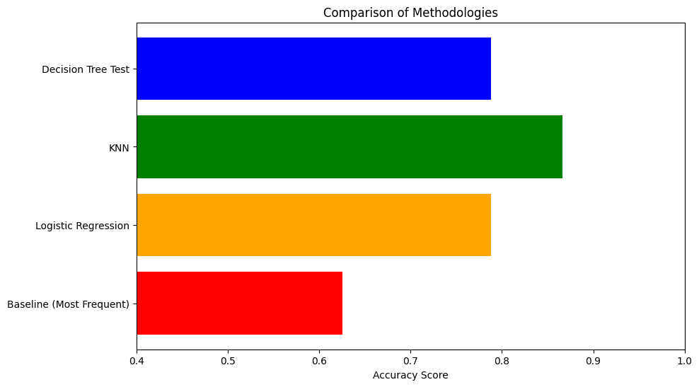

```python
methods = ['Decision Tree Test', 'KNN', 'Logistic Regression', 'Baseline (Most Frequent)']
accuracy_scores = [ test_score, acc_knn, acc_lr, dummy_score]

plt.figure(figsize=(10, 6))
plt.barh(methods, accuracy_scores, color=['blue', 'green', 'orange', 'red', 'gray'])
plt.xlabel('Accuracy Score')
plt.title('Comparison of Methodologies')
plt.xlim(0.4, 1)  # Set the x-axis limit to better visualize the differences, including baseline
plt.gca().invert_yaxis()  # Invert y-axis to have Decision Tree Train at the top
plt.show()
```

And as you may have noticed earlier, K Nearest Neighborhs is in a comfortable lead, while decision trees and logistic regression are close to one another. However, due to the decision tree's tendency to overfit, I wold say that this do not represent quite represnt the difference in efficacy between the two.

```python
model = RandomForestRegressor()  # Or RandomForestClassifier for classification
model.fit(X_train, y_train)

# Get feature importances
feature_importances = model.feature_importances_

# Combine with feature names
feature_importance_dict = dict(zip(X_train.columns, feature_importances))

# Sort feature importance dictionary by values
sorted_feature_importance = sorted(feature_importance_dict.items(), key=lambda x: x[1], reverse=True)

# Print or visualize feature importance
print("Feature Importance:")
for feature, importance in sorted_feature_importance:
    print(f"{feature}: {importance}")
```

```
Feature Importance:
lead_time: 0.4258346022732025
adr: 0.366352417320363
total_of_special_requests: 0.09099759443031828
previous_cancellations: 0.06361112928591875
adults: 0.038499263294189366
previous_bookings_not_canceled: 0.013093188164524011
is_repeated_guest: 0.001611805231484136
```

Breaking down all of our models performance and variations, it's clear that K nearest neighborghs is the best option for prediciting cancellations by a prety wide margin. But why is that?

1. Dimensionality: KNN is a way to basically plot points in space and see which points are most similar by proximity: by cleaning the data properly and seeing whether or not something actually resembles the "situation" of a reservation, we are able to get more accurate depictions of what "might" happen- hence why the model performed so strongly. This is something that both linear regressin and decision trees lack and lets go through each one:
2. In the case of the linear regression, its possible that the clasification boundrarary for what actually makes a reservation more likely to cancel isnt very linear: in real life, this makes sense. There are alot of factors and correlations that go into somebody deciding to finally cancel a booking. While linear regression can clearly estimate this chance on some level, KNN is much more able to contextualize a data point in comparison to other ones.
3. Aditionally, there is alot of ordinality in this dataset whether we like it or not, those may have had a huge influence in the regressions decisions when attending to certain values, where KNN is may have been able to actually group situations together, linear regresssion kind of just pushes the model to belive something is true, and not much other influence is taken into consideration.
4. In the case of a decision tree, I personally believe that this approach is inherently flawed: decision trees are higly prone to overfitting,and with a dataset as varied and also large as this one, overfitting for certain fluctuations may have led the model to ahve subpar performance. The tree is inehrently just a reprsentation of the dataset, and with larger depth the performance was only marginally getting better, represetnaive that the structure itself does not suit itself to a problem asmulti-facedted as this one, especially when certain values are not actually related to one another. With KNN, these values get implcitly grouped together, but in actual priroty that makes sene becuse they are all hosted in an actual space, not a graph.

# Insights and Conclusions

For some short conclusions after analzying everything here are important things we observed:

1. For hotel bookings, dimensionality / non linearity seems to be important to getting a better understanding/world view of the imformation itself.
2. Portugal is not a good place to start a hotel business compared to the rest of the world, they see by far the most cancellations and incosistent booking.
3. Linear regression is a decent tool for getting a quick judgements, if you possibly do not have alot of computing power/need to streamline the process.

For more resources to better undestand data science/this problem, please visit the following:

https://www.youtube.com/watch?v=YqYrQf17eMY&list=PLx9ZWY6gSs_4_afndWKzyEZrjrWiOsbyL

https://www.analyticsvidhya.com/blog/2018/03/introduction-k-neighbours-algorithm-clustering/

https://www.mathworks.com/campaigns/offers/next/choosing-the-best-machine-learning-classification-model-and-avoiding-overfitting.html#:~:text=Classification%20models%20are%20used%20to,a%20specific%20set%20of%20features.